# Multiclass Classification - Trees Classifier Models

# Evaluating the Performance of the Classifier Model

**Classification metrics** evaluate the performance of machine learning models that categorize data into distinct classes. Key metrics include accuracy (overall correctness), precision (correct positive predictions), recall/sensitivity (finding all positive samples), and the F1-score (harmonic mean of precision and recall). The choice of metric depends on class balance.

### Key Classification Metrics:

- **Accuracy**: Percentage of correct predictions out of all predictions. It is best for balanced datasets.
- **Precision**: Proportion of true positive predictions among all positive predictions. Use this when the cost of false positives is high.
- **Recall** (Sensitivity): Proportion of true positive predictions among all actual positive instances.
- **F1-Score**: The harmonic mean of precision and recall, balancing both measures. Ideal for imbalanced data.

```python
# Print the performance metrics such as accuracy, precision, recall, and F1-score
from sklearn.metrics import accuracy_score, precision_score, recall_score, f1_score
import seaborn as sns
import matplotlib.pyplot as plt

# Create a dataframe to hold the classification metrics for each model
metrics_df = pd.DataFrame({
    'Model': ['Decision Tree', 'Random Forest', 'Extra Trees'],
    'Accuracy': [f'{score:.2f}%' for score in [
        accuracy_score(y_test, dt_clf.predict(X_test.astype('float32'))) * 100.00,
        accuracy_score(y_test, rf_clf.predict(X_test.astype('float32'))) * 100.00,
        accuracy_score(y_test, et_clf.predict(X_test.astype('float32'))) * 100.00
    ]],
    'Precision': [f'{score:.2f}%' for score in [
        precision_score(y_test, dt_clf.predict(X_test.astype('float32')), average='weighted') * 100.00,
        precision_score(y_test, rf_clf.predict(X_test.astype('float32')), average='weighted') * 100.00,
        precision_score(y_test, et_clf.predict(X_test.astype('float32')), average='weighted') * 100.00
    ]],
    'Recall': [f'{score:.2f}%' for score in [
        recall_score(y_test, dt_clf.predict(X_test.astype('float32')), average='weighted') * 100.00,
        recall_score(y_test, rf_clf.predict(X_test.astype('float32')), average='weighted') * 100.00,
        recall_score(y_test, et_clf.predict(X_test.astype('float32')), average='weighted') * 100.00
    ]],
    'F1 Score': [f'{score:.2f}%' for score in [
        f1_score(y_test, dt_clf.predict(X_test.astype('float32')), average='weighted') * 100.00,
        f1_score(y_test, rf_clf.predict(X_test.astype('float32')), average='weighted') * 100.00,
        f1_score(y_test, et_clf.predict(X_test.astype('float32')), average='weighted') * 100.00
    ]]
})

# Display the metrics dataframe
metrics_df.style.hide(axis='index')
```

| Model | Accuracy | Precision | Recall | F1 Score |
| --- | --- | --- | --- | --- |
| Decision Tree | 96.67% | 96.97% | 96.67% | 96.66% |
| Random Forest | 96.67% | 96.97% | 96.67% | 96.66% |
| Extra Trees | 93.33% | 93.33% | 93.33% | 93.33% |

# Confusion Matrix

A confusion matrix is a useful tool for evaluating the performance of a classification model. It provides a summary of prediction results on a classification problem, showing the number of correct and incorrect predictions broken down by each class.

**Key Points:**

- Each row of the matrix represents the instances in an actual class, while each column represents the instances in a predicted class.
- The diagonal elements represent the number of points for which the predicted label is equal to the true label (correct predictions).
- Off-diagonal elements are those that are mislabeled by the classifier.

**Why use a confusion matrix?**

- To visualize the performance of a classification algorithm.
- To identify types of errors made by the model (e.g., which classes are most often confused).
- To compute important metrics such as accuracy, precision, recall, and F1-score.

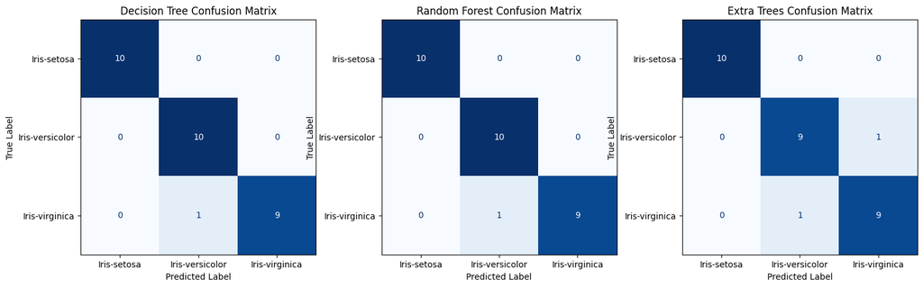

```python
# Confusion Matrix and Classification Report
from sklearn.metrics import confusion_matrix, ConfusionMatrixDisplay

# Compute the confusion matrix for each model
dt_conf_matrix = confusion_matrix(y_test, dt_clf.predict(X_test.astype('float32')))
rf_conf_matrix = confusion_matrix(y_test, rf_clf.predict(X_test.astype('float32')))
et_conf_matrix = confusion_matrix(y_test, et_clf.predict(X_test.astype('float32')))

# Create a list of models and their corresponding predictions
models = ['Decision Tree', 'Random Forest', 'Extra Trees']
predictions = [dt_clf.predict(X_test.astype('float32')), rf_clf.predict(X_test.astype('float32')), et_clf.predict(X_test.astype('float32'))]

# Create subplots for confusion matrices
fig, axes = plt.subplots(1, 3, figsize=(18, 5))

# Plot confusion matrices for each model
for i, (model, pred) in enumerate(zip(models, predictions)):
    conf_matrix = confusion_matrix(y_test, pred)
    disp = ConfusionMatrixDisplay(confusion_matrix=conf_matrix, display_labels=dt_clf.classes_)
    disp.plot(ax=axes[i], cmap='Blues', colorbar=False)
    axes[i].set_title(f'{model} Confusion Matrix')
    axes[i].set_xlabel('Predicted Label')
    axes[i].set_ylabel('True Label')
plt.show()
```

## Random Sample Prediction

Below, we select a random sample from the test set and use the trained model to predict its class. The predicted class and the true class are compared to assess the model's performance on individual samples.

```python
# Generate a random number ranges from the test set for inference
import numpy as np
random_index = np.random.randint(0, X_test.shape[0])

# Extract the corresponding test sample and its true label
X_test_sample = X_test[random_index:random_index+1]
y_test_sample = y_test[random_index:random_index+1]

# Perform prediction using sample test sample for each model
dt_pred = dt_clf.predict(X_test_sample)
rf_pred = rf_clf.predict(X_test_sample)
et_pred = et_clf.predict(X_test_sample)

# Compute for probabilities for the sample test sample for each model
dt_prob = dt_clf.predict_proba(X_test_sample)
rf_prob = rf_clf.predict_proba(X_test_sample)
et_prob = et_clf.predict_proba(X_test_sample)

# Get the index of the predicted class
pred_class_idx = np.argmax(dt_prob[0])

# Create a dataframe to hold the test sample and its true label
test_sample_df = pd.DataFrame({'Features': [X_test_sample.astype('float32').to_csv(index=False, header=False).strip()],
                               'True Label': [y_test_sample.values[0]],
                               'Predicted Label (DT)': [dt_pred[0]],
                               'Predicted Label (RF)': [rf_pred[0]],
                               'Predicted Label (ET)': [et_pred[0]],
                               'Probability (DT)': [float(dt_prob[0, pred_class_idx] * 100)],
                               'Probability (RF)': [float(rf_prob[0, pred_class_idx] * 100)],
                               'Probability (ET)': [float(et_prob[0, pred_class_idx] * 100)]})

# Display the test sample dataframe
test_sample_df.style.hide(axis='index').format({'Probability (DT)': '{:.2f}%', 'Probability (RF)': '{:.2f}%', 'Probability (ET)': '{:.2f}%'})
```

| Features | True Label | Predicted Label (DT) | Predicted Label (RF) | Predicted Label (ET) | Probability (DT) | Probability (RF) | Probability (ET) |
| --- | --- | --- | --- | --- | --- | --- | --- |
| 6.1,2.8,4.7,1.2 | Iris-versicolor | Iris-versicolor | Iris-versicolor | Iris-versicolor | 100.00% | 100.00% | 98.69% |

# Visualizing the Model Decision Boundary

Visualizing ensemble multiclass classification decision boundaries involves plotting the high-dimensional model's predictions over a 2D meshgrid using tools like scikit-learn's `DecisionBoundaryDisplay`. This technique divides the feature space into regions representing each class, defining where the model changes predictions to show smoother, non-linear boundaries. For multiclass, this is often a complex, multi-segmented surface. When data has more than tow (2) features, technique like `Principal Component Analysis` (PCA) or `feature selection` is needed to plot boundaries on a 2D plot.

[figure not shown]

```python
# Import kbest from scikit-learn for feature selection
from sklearn.feature_selection import SelectKBest, f_classif

# Select the top 2 features using ANOVA F-value
selector = SelectKBest(score_func=f_classif, k=2)

# Fit and transform the training and test features using SelectKBest
X_train_selected = selector.fit_transform(X_train, y_train)
X_test_selected = selector.transform(X_test)

# Retrain the models using the selected features
dt_clf_selected = DecisionTreeClassifier(random_state=42, max_depth=10)
dt_clf_selected.fit(X_train_selected, y_train)
rf_clf_selected = RandomForestClassifier(n_estimators=30, random_state=42, max_depth=10)
rf_clf_selected.fit(X_train_selected, y_train)
et_clf_selected = ExtraTreesClassifier(n_estimators=30, random_state=42, max_depth=10)
et_clf_selected.fit(X_train_selected, y_train)

# Import the DecisionBoundaryDisplay from scikit-learn
from sklearn.inspection import DecisionBoundaryDisplay

# Compute the decision boundary for each model using DecisionBoundaryDisplay
fig, axes = plt.subplots(1, 3, figsize=(18, 5))

# Transform the inference sample to the same selected feature space
X_test_sample_selected = selector.transform(X_test_sample)

for i, (model, clf) in enumerate(zip(models, [dt_clf_selected, rf_clf_selected, et_clf_selected])):
    disp = DecisionBoundaryDisplay.from_estimator(clf,
                                                  X_test_selected,
                                                  response_method='predict_proba',
                                                  plot_method='contourf',
                                                  grid_resolution=100,
                                                  ax=axes[i],
                                                  alpha=0.7)

    # Overlay the test samples on the decision boundary plot
    sns.scatterplot(x=X_test_selected[:, 0], y=X_test_selected[:, 1], hue=y_test, palette='Set1', style=y_test, markers=['o', 's', '^'], s=100, ax=axes[i])
    # Highlight the specific test sample used for inference
    sns.scatterplot(x=X_test_sample_selected[:, 0], y=X_test_sample_selected[:, 1], color='m', marker='X', s=200, label='Test Sample', ax=axes[i])
    axes[i].set_title(f'{model} Decision Boundary')
    axes[i].set_xlabel('Petal Length')
    axes[i].set_ylabel('Petal Width')
    axes[i].legend()
    axes[i].set_xlim(1.0, 7.5)
    axes[i].set_ylim(0.0, 3.0)
plt.show()
```

# Port the Classifier Model to C Code

## emlearn - Machine Learning for Tiny Embedded Systems

`emlearn` is an open-source Python library that allows converting scikit-learn and Keras models to efficient C code. This makes it easy to deploy to any microcontroller with, while keeping Python-based workflow that is familiar to Machine Learning Engineers.

To install emlearn to convert models in Python, use `pip install emlearn`

```python
# Convert model using emlearn
import emlearn

# Convert the trained Decision Tree model to C++ code using emlearn
dt_clf_c_model = emlearn.convert(dt_clf, method='inline', dtype='float', return_type='classifier')

# Generate and save the C code to a header file
dt_clf_c_code = dt_clf_c_model.save(file='DecisionTreeClassifier.h', name='DecisionTreeClassifier')

# Print the generated C code
print(dt_clf_c_code)
```

```
    // !!! This file is generated using emlearn !!!

    #include <stdint.h>


static inline int32_t DecisionTreeClassifier_tree_0(const float *features, int32_t features_length) {
          if (features[2] < 2.450000f) {
              return 0;
          } else {
              if (features[3] < 1.750000f) {
                  if (features[2] < 5.350000f) {
                      if (features[0] < 4.950000f) {
                          if (features[1] < 2.450000f) {
                              return 1;
                          } else {
                              return 2;
                          }
                      } else {
                          if (features[2] < 4.950000f) {
                              return 1;
                          } else {
                              if (features[1] < 2.450000f) {
                                  return 2;
                              } else {
                                  return 1;
                              }
                          }
                      }
                  } else {
                      return 2;
                  }
              } else {
                  if (features[2] < 4.850000f) {
                      if (features[1] < 3.100000f) {
                          return 2;
                      } else {
                          return 1;
                      }
                  } else {
                      return 2;
```

[output cut: 27 more lines]

```

        int32_t _class = -1;

        for (int i=0; i<out_length; i++) {
            out[i] = 0.0f;
        }

        _class = DecisionTreeClassifier_tree_0(features, features_length); out[_class] += 1.0f;

        // compute mean
        for (int i=0; i<out_length; i++) {
            out[i] = out[i] / 1;
        }
        return 0;
    }
```

```python
# Convert the trained Random Forest model to C++ code using emlearn
rf_clf_c_model = emlearn.convert(rf_clf, method='inline', dtype='float', return_type='classifier')

# Generate and save the C code to a header file
rf_clf_c_code = rf_clf_c_model.save(file='RandomForestClassifier.h', name='RandomForestClassifier')

# Print the generated C code
print(rf_clf_c_code)
```

```
    // !!! This file is generated using emlearn !!!

    #include <stdint.h>


static inline int32_t RandomForestClassifier_tree_0(const float *features, int32_t features_length) {
          if (features[3] < 1.750000f) {
              if (features[3] < 0.800000f) {
                  return 0;
              } else {
                  if (features[2] < 5.350000f) {
                      if (features[3] < 1.450000f) {
                          return 1;
                      } else {
                          if (features[1] < 2.350000f) {
                              return 2;
                          } else {
                              return 1;
                          }
                      }
                  } else {
                      return 2;
                  }
              }
          } else {
              return 2;
          }
        }


static inline int32_t RandomForestClassifier_tree_1(const float *features, int32_t features_length) {
          if (features[2] < 2.450000f) {
              return 0;
          } else {
              if (features[3] < 1.700000f) {
                  return 1;
              } else {
                  return 2;
              }
          }
```

[output cut: 1034 more lines]

```
    _class = RandomForestClassifier_tree_22(features, features_length); out[_class] += 1.0f;
    _class = RandomForestClassifier_tree_23(features, features_length); out[_class] += 1.0f;
    _class = RandomForestClassifier_tree_24(features, features_length); out[_class] += 1.0f;
    _class = RandomForestClassifier_tree_25(features, features_length); out[_class] += 1.0f;
    _class = RandomForestClassifier_tree_26(features, features_length); out[_class] += 1.0f;
    _class = RandomForestClassifier_tree_27(features, features_length); out[_class] += 1.0f;
    _class = RandomForestClassifier_tree_28(features, features_length); out[_class] += 1.0f;
    _class = RandomForestClassifier_tree_29(features, features_length); out[_class] += 1.0f;

        // compute mean
        for (int i=0; i<out_length; i++) {
            out[i] = out[i] / 30;
        }
        return 0;
    }
```

```python
# Convert the trained Extra Trees model to C++ code using emlearn
et_clf_c_model = emlearn.convert(et_clf, method='inline', dtype='double', return_type='classifier')

# Generate and save the C code to a header file
et_clf_c_code = et_clf_c_model.save(file='ExtraTreesClassifier.h', name='ExtraTreesClassifier')

# Print the generated C code
print(et_clf_c_code)
```

```
    // !!! This file is generated using emlearn !!!

    #include <stdint.h>


static inline int32_t ExtraTreesClassifier_tree_0(const double *features, int32_t features_length) {
          if (features[0] < 5.73171695861171) {
              if (features[3] < 0.7522900654718728) {
                  return 0;
              } else {
                  if (features[0] < 5.583514650419424) {
                      if (features[2] < 4.393862795966614) {
                          return 1;
                      } else {
                          if (features[1] < 2.5535604953586875) {
                              return 2;
                          } else {
                              return 1;
                          }
                      }
                  } else {
                      if (features[3] < 1.701681204466932) {
                          return 1;
                      } else {
                          return 2;
                      }
                  }
              }
          } else {
              if (features[2] < 2.8734523737292026) {
                  return 0;
              } else {
                  if (features[2] < 5.387322759780195) {
                      if (features[3] < 2.119696856716341) {
                          if (features[0] < 6.550308839345777) {
                              if (features[0] < 6.195533182030621) {
                                  if (features[2] < 4.464176336858416) {
                                      return 1;
                                  } else {
                                      if (features[0] < 5.8901776613698065) {
```

[output cut: 2314 more lines]

```
    _class = ExtraTreesClassifier_tree_22(features, features_length); out[_class] += 1.0f;
    _class = ExtraTreesClassifier_tree_23(features, features_length); out[_class] += 1.0f;
    _class = ExtraTreesClassifier_tree_24(features, features_length); out[_class] += 1.0f;
    _class = ExtraTreesClassifier_tree_25(features, features_length); out[_class] += 1.0f;
    _class = ExtraTreesClassifier_tree_26(features, features_length); out[_class] += 1.0f;
    _class = ExtraTreesClassifier_tree_27(features, features_length); out[_class] += 1.0f;
    _class = ExtraTreesClassifier_tree_28(features, features_length); out[_class] += 1.0f;
    _class = ExtraTreesClassifier_tree_29(features, features_length); out[_class] += 1.0f;

        // compute mean
        for (int i=0; i<out_length; i++) {
            out[i] = out[i] / 30;
        }
        return 0;
    }
```